# In SVC for multiclass classification, the data is trained for combination of two classes . For example, class 0 and class 1, class 0 and class 2 etc.,. So SVC learns to distinguish between two different classes

# Linear SVC is one-vs-the-rest

# Here Class 0 is considered as positive class and all the other classes are considered as negative class

# Linear SVC(i)

```python
import numpy as np
from mnist import MNIST
import matplotlib.pyplot as plt
import pandas as pd
import pickle
import time
from sklearn import svm
from sklearn import model_selection
```

```python
mndata = MNIST('./samples')

images, labels = mndata.load_training()

testimages, testlabls = mndata.load_testing()
```

```python
train = np.array(images,dtype='uint8')
trainlabels=np.array(labels,dtype='uint8')
test = np.array(testimages,dtype='uint8')
testlabels=np.array(testlabls,dtype='uint8')
```

```python
def accuracy(labels,truelabels):
    count= len(np.where(labels-truelabels==0)[0])
    return (count/len(labels))*100
```

```python
c_vec=[0.01,0.05,0.1,0.5,1,10,25,50,100,250,500,1000]
```

```python
clf=[]
for i in range(len(c_vec)):
    clf.insert(i,svm.LinearSVC(C=c_vec[i],dual=False))
    clf[i].fit(train,trainlabels)
```

with open('./l_svm_models.p', 'wb') as y: pickle.dump(clf, y)

```python
with open('./l_svm_models.p', 'rb') as y:
    clf = pickle.load(y)
```

```python
testpred=[]
testacc=[]
trainpred=[]
trainacc=[]
coef=[]
for i in range(len(c_vec)):
    testpred.insert(i,clf[i].predict(test))
    testacc.insert(i,accuracy(testpred[i],testlabels))
    trainpred.insert(i,clf[i].predict(train))
    trainacc.insert(i,accuracy(trainpred[i],trainlabels))
    coef.insert(i,clf[i].coef_)
```

```python
testacc=np.array(testacc)
trainacc=np.array(trainacc)
cvec=np.array(cvec)
```

```python
testacc=np.array(testacc).reshape([12,1])
trainacc=np.array(trainacc).reshape([12,1])
z=np.concatenate((testacc,trainacc),axis=1)
z=np.concatenate((np.array(c_vec).reshape([12,1]),z),axis=1)
p=pd.DataFrame(z)
#p.index=c_vec
p.columns=['C values','test accuracy','train accuracy']
p
```

|  | C values | test accuracy | train accuracy |
| --- | --- | --- | --- |
| 0 | 0.01 | 91.72 | 92.768333 |
| 1 | 0.05 | 91.74 | 92.771667 |
| 2 | 0.10 | 91.72 | 92.755000 |
| 3 | 0.50 | 91.69 | 92.756667 |
| 4 | 1.00 | 91.70 | 92.743333 |
| 5 | 10.00 | 91.70 | 92.763333 |
| 6 | 25.00 | 91.70 | 92.735000 |
| 7 | 50.00 | 91.72 | 92.768333 |
| 8 | 100.00 | 91.63 | 92.776667 |
| 9 | 250.00 | 91.75 | 92.776667 |
| 10 | 500.00 | 91.72 | 92.776667 |
| 11 | 1000.00 | 91.73 | 92.766667 |

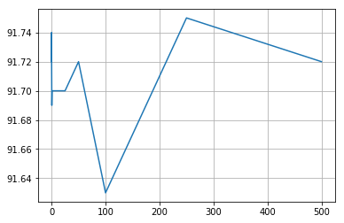

```python
plt.plot(c_vec[0:11],testacc[0:11])
plt.grid()
plt.show()
```

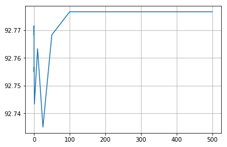

```python
plt.plot(c_vec[0:11],trainacc[0:11])
plt.grid()
plt.show()
```

### There is a good trade off of viarance and bias at C=250, I would choose C=250

# coefficients Linear SVC with L2 regularization

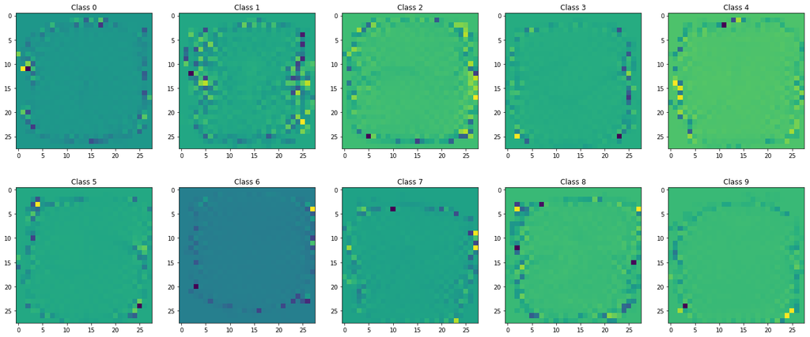

```python
plt.subplots(2,5,figsize=(24,10))
for i in range(10):
    sub=plt.subplot(2,5,i+1)
    plt.title('Class %d' %i)
    w=coef[1][i]
    sub.imshow(w.reshape(28,28))
plt.show()
```

### These Coefficients are not similar to what I got in logistic regression.

### In logistic regression the plots were blurry , yet the class label was easy to distinguish

### But here in SVM , it hard to distinguish which class it belongs to

# LinearSVC with l1 regularization(iii)

```python
c_vec=[0.01,0.05,0.1,0.5,1,10,25,50,100,250,500,1000]
```

```python
clf_l1=[]
for i in range(len(c_vec)):
    clf_l1.insert(i,svm.LinearSVC(C=c_vec[i],dual=False,penalty='l1'))
    clf_l1[i].fit(train,trainlabels)
```

with open('./l_svml1_models.p', 'wb') as y: pickle.dump(clf_l1, y)

```python
with open('./l_svml1_models.p', 'rb') as y:
    clf_l1 = pickle.load(y)
```

```python
testpredl1=[]
testaccl1=[]
trainpredl1=[]
trainaccl1=[]
coefl1=[]
for i in range(len(c_vec)):
    testpredl1.insert(i,clf_l1[i].predict(test))
    testaccl1.insert(i,accuracy(testpredl1[i],testlabels))
    trainpredl1.insert(i,clf_l1[i].predict(train))
    trainaccl1.insert(i,accuracy(trainpredl1[i],trainlabels))
    coefl1.insert(i,clf_l1[i].coef_)
```

```python
testaccl1=np.array(testaccl1).reshape([12,1])
trainaccl1=np.array(trainaccl1).reshape([12,1])
z=np.concatenate((testaccl1,trainaccl1),axis=1)
z=np.concatenate((np.array(c_vec).reshape([12,1]),z),axis=1)
p=pd.DataFrame(z)
#p.index=c_vec
p.columns=['C values','test accuracy','train accuracy']
p
```

|  | C values | test accuracy | train accuracy |
| --- | --- | --- | --- |
| 0 | 0.01 | 91.81 | 92.685000 |
| 1 | 0.05 | 91.72 | 92.738333 |
| 2 | 0.10 | 91.74 | 92.763333 |
| 3 | 0.50 | 91.67 | 92.783333 |
| 4 | 1.00 | 91.66 | 92.788333 |
| 5 | 10.00 | 91.60 | 92.793333 |
| 6 | 25.00 | 91.60 | 92.795000 |
| 7 | 50.00 | 91.60 | 92.793333 |
| 8 | 100.00 | 91.60 | 92.795000 |
| 9 | 250.00 | 91.61 | 92.796667 |
| 10 | 500.00 | 91.60 | 92.796667 |
| 11 | 1000.00 | 91.60 | 92.795000 |

# Cost paramater V/s Test Accuracy

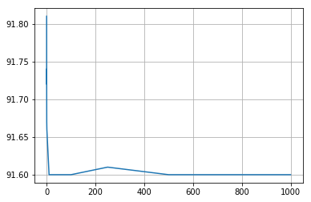

```python
plt.plot(c_vec,testaccl1)
plt.grid()
plt.show()
```

# Cost paramater V/s Train Accuracy

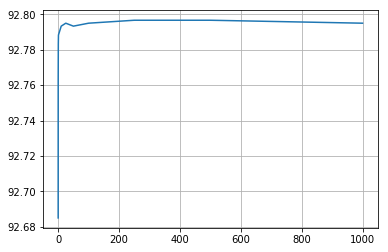

```python
plt.plot(c_vec,trainaccl1)
plt.grid()
plt.show()
```

### Clearly from the accuracy v/s cost parameter plots, we can see that as C increases, Accuracy increased for train data , accuracy decreased for test data.

### This means there was overfitting when C value increased. So the variance increased and bias decreased as C values increased

### there is a good trade off of bias and variance at C= 0.01

# Linear SVC WITH L1 COEFFICIENTS

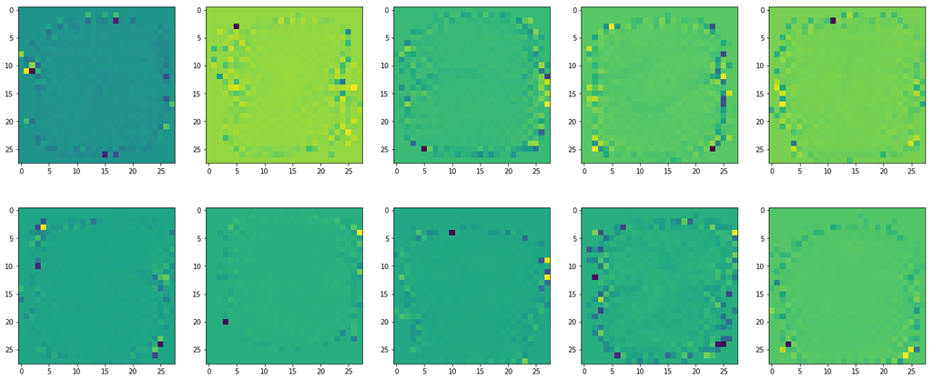

```python
plt.subplots(2,5,figsize=(24,10))
for i in range(10):
    sub=plt.subplot(2,5,i+1)
    w=coefl1[1][i]
    sub.imshow(w.reshape(28,28))
plt.show()
```

### These Coefficients are not similar to what I got in logistic regression.

### In logistic regression the plots were blurry , yet the class label was easy to distinguish

### But here in SVM , it hard to distinguish which class it belongs to

# L1 regularization V/s L2 regularization

## The best accuracy of L1 is 91.8 and for L2 it is 91.7

## L1 penalty gives goods results compared to L2 regularization

# SVC_RBF

```python
train = np.array(images,dtype='uint8')
trainlabels=np.array(labels,dtype='uint8')
test = np.array(testimages,dtype='uint8')
testlabels=np.array(testlabls,dtype='uint8')
```

```python
train=train/255
test=test/255
trainindex=np.random.randint(0,60000,10000)
t=train[trainindex,:]
tl=trainlabels[trainindex]
print(tl.shape)
```

```
(10000,)
```

```python
start = time.time()
clf_rbf=svm.SVC(C=5,gamma=0.05)
clf_rbf.fit(t,tl)
pred=clf_rbf.predict(test)
print(accuracy(pred,testlabels))
end = time.time()
print(end - start)
```

```
96.53
109.1712338924408
```

```python
gamma_range = np.outer(np.logspace(-3, 0, 4),np.array([1,5]))
gamma_range = gamma_range.flatten()
x=[1,3,5,6,7]
gamma_range=gamma_range[x]
cvec=[0.01,0.1,1,5,1000]

print(cvec)
print(gamma_range)
```

```
[0.01, 0.1, 1, 5, 1000]
[ 0.005  0.05   0.5    1.     5.   ]
```

```python
start = time.time()
clf_rbf=[]
for i in range(len(gamma_range)):
    clf_gamma=[]
    for j in range(len(cvec)):
        clf_gamma.insert(j,svm.SVC(C=cvec[j],kernel='rbf',gamma=gamma_range[i]))
        clf_gamma[j].fit(t,tl)
    clf_rbf.insert(i,clf_gamma)
end = time.time()
print(end - start)
```

```
2655.1040573120117
```

```python
pred=clf_rbf1[1][3].predict(t)
print(accuracy(pred,tl))
```

[output not shown]

```python
start1 = time.time()
with open('./svmrbf_models.p', 'wb') as y:
    pickle.dump(clf_rbf, y)
end1 = time.time()
print(end1 - start1)
```

```
38.587236642837524
```

```python
start = time.time()
trainacc_rbf=[]
testacc_rbf=[]
for i in range(len(gamma_range)):
    traintemp=[]
    testtemp=[]
    for j in range(len(cvec)):
        predtest=clf_rbf[i][j].predict(test)
        testtemp.insert(j,accuracy(predtest,testlabels))
        predtrain=clf_rbf[i][j].predict(t)
        traintemp.insert(j,accuracy(predtrain,tl))
    trainacc_rbf.insert(i,traintemp)
    testacc_rbf.insert(i,testtemp)
end = time.time()
print(end - start)
```

```
3266.271113872528
```

```python
with open('./svmrbf_models.p', 'wb') as y:
    pickle.dump(clf_rbf, y)
```

```python
rbf_train=np.array(trainacc_rbf).reshape([5,5])
rbf_test=np.array(testacc_rbf).reshape([5,5])
```

```python
rbftraindt=pd.DataFrame(rbf_train)
rbftraindt.columns = ['C=0.01', 'C=0.1','C=1','C=5','C=1000']
rbftraindt.index = ['Gamma=0.005', 'Gamma=0.05','Gamma=0.5','Gamma=1','Gamma=5']
rbftestdt=pd.DataFrame(rbf_test)
rbftestdt.columns = ['C=0.01', 'C=0.1','C=1','C=5','C=1000']
rbftestdt.index = ['Gamma=0.005', 'Gamma=0.05','Gamma=0.5','Gamma=1','Gamma=5']
```

# Values of train accuracy for different values of gamma and C

```python
rbftraindt
```

|  | C=0.01 | C=0.1 | C=1 | C=5 | C=1000 |
| --- | --- | --- | --- | --- | --- |
| Gamma=0.005 | 71.79 | 90.22 | 94.11 | 95.68 | 96.06 |
| Gamma=0.05 | 28.89 | 90.19 | 96.80 | 96.91 | 96.91 |
| Gamma=0.5 | 11.16 | 11.16 | 30.83 | 31.19 | 31.19 |
| Gamma=1 | 11.16 | 11.16 | 30.87 | 30.92 | 30.92 |
| Gamma=5 | 11.16 | 11.16 | 24.52 | 24.52 | 24.52 |

# Values of test accuracy for different values of gamma and C

```python
rbftestdt
```

|  | C=0.01 | C=0.1 | C=1 | C=5 | C=1000 |
| --- | --- | --- | --- | --- | --- |
| Gamma=0.005 | 71.92 | 91.45 | 94.70 | 95.84 | 95.74 |
| Gamma=0.05 | 28.37 | 90.45 | 96.43 | 96.53 | 96.53 |
| Gamma=0.5 | 11.35 | 11.35 | 18.72 | 18.96 | 18.96 |
| Gamma=1 | 11.35 | 11.35 | 18.63 | 18.82 | 18.82 |
| Gamma=5 | 11.35 | 11.35 | 11.35 | 11.35 | 11.35 |

### For a constant gamma value, as C values increases , the accuracy for both test and train increases.

### So clearly bias decreased ,variance increased as C increased for a constant gamma value (looking at train accuracy).

### Comparing to Linear SVC, SVC with RBF kernel gives good accuracy.

### I would choose gamma=0.05 and C= 1000 as it gives best accuracy for test data

with open('./svmrbf_models.p', 'rb') as y: clf_rbf1 = pickle.load(y)

```python
nsupp=clf_rbf[1][4].n_support_
print(nsupp)
suppvec=clf_rbf[1][4].support_vectors_
print(suppvec.shape)
dual=clf_rbf[1][4].dual_coef_
print(len(dual[1]))
#print(len(np.where(dual>0)[0]))
```

```
[579 212 751 667 705 775 606 542 746 682]
(6265, 784)
6265
```

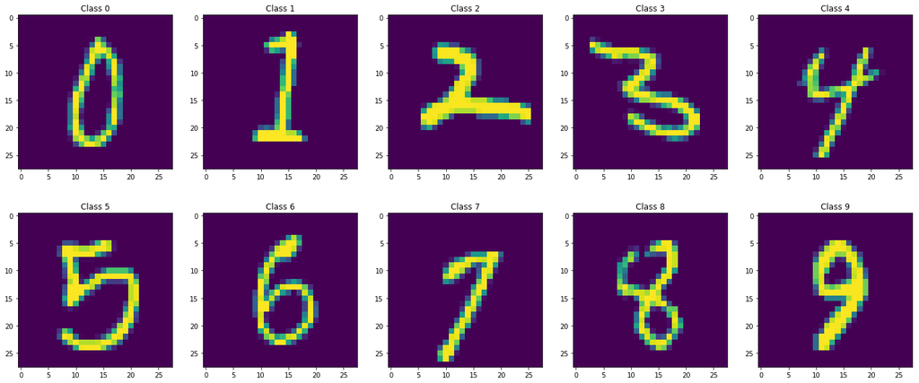

```python
j=0
plt.subplots(2,5,figsize=(24,10))
for i in range(10):
    sub=plt.subplot(2,5,i+1)
    w=suppvec[j]
    j=j+nsupp[i]+3
    plt.title('Class %d' %i)
    sub.imshow(w.reshape(28,28))
plt.show()
```

### There are 6265 support vectors and the alpha values (dual coefficient) is 9X6265 matrix

# SVC_poly

```python
train1 = np.array(images,dtype='uint8')
trainlabels=np.array(labels,dtype='uint8')
test1 = np.array(testimages,dtype='uint8')
testlabels=np.array(testlabls,dtype='uint8')
```

```python
train=train/255
test=test/255
trainindex=np.random.randint(0,60000,10000)
t=train1[trainindex,:]
tl=trainlabels[trainindex]
print(tl.shape)
```

```python
deg_range=[2,3,4,5,6,7,8]

cvec=[0.05,0.5,5,50,500]

print(cvec)
print(deg_range)
```

```
[0.05, 0.5, 5, 50, 500]
[2, 3, 4, 5, 6, 7, 8]
```

```python
start = time.time()
clf_poly=[]
for i in range(len(deg_range)):
    clf_deg=[]
    for j in range(len(cvec)):
        clf_deg.insert(j,svm.SVC(C=cvec[j],kernel='poly',degree=deg_range[i]))
        clf_deg[j].fit(t,tl)
    clf_poly.insert(i,clf_deg)
end = time.time()
print(end - start)
```

[output not shown]

```python
start1 = time.time()
with open('./svmpoly_models.p', 'wb') as y:
    pickle.dump(clf_poly, y)
end1 = time.time()
print(end1 - start1)
```

```python
with open('./svmpoly_models.p', 'rb') as y:
    clf_poly1 = pickle.load(y)
```

```python
start = time.time()
trainacc_poly=[]
testacc_poly=[]
for i in range(len(deg_range)):
    traintemp=[]
    testtemp=[]
    for j in range(len(cvec)):
        predtest=clf_poly1[i][j].predict(test)
        testtemp.insert(j,accuracy(predtest,testlabels))
        predtrain=clf_poly1[i][j].predict(t)
        traintemp.insert(j,accuracy(predtrain,tl))
    trainacc_poly.insert(i,traintemp)
    testacc_poly.insert(i,testtemp)
end = time.time()
print(end - start)
```

[output not shown]

```python
with open('./svmpoly_trainacc.p', 'wb') as y:
    pickle.dump(trainacc_poly, y)
with open('./svmpoly_testacc.p', 'wb') as y:
    pickle.dump(testacc_poly, y)
```

```python
with open('./svmpoly_trainacc.p', 'rb') as y:
    trainaccpoly = pickle.load(y)
with open('./svmpoly_testacc.p', 'rb') as y:
    testaccpoly = pickle.load(y)
```

```python
poly_train=np.array(trainaccpoly).reshape([7,5])
poly_test=np.array(testaccpoly).reshape([7,5])
```

```python
polytraindt=pd.DataFrame(poly_train)
polytraindt.columns = ['C=0.05', 'C=0.5','C=5','C=50','C=500']
polytraindt.index = ['degree=2', 'degree=3','degree=4','degree=5','degree=6','degree=7','degree=8']
polytestdt=pd.DataFrame(poly_test)
polytestdt.columns = ['C=0.05', 'C=0.5','C=5','C=50','C=500']
polytestdt.index = ['degree=2', 'degree=3','degree=4','degree=5','degree=6','degree=7','degree=8']
```

# Values of train accuracy for different values of degree and C

```python
polytraindt
```

|  | C=0.05 | C=0.5 | C=5 | C=50 | C=500 |
| --- | --- | --- | --- | --- | --- |
| degree=2 | 11.91 | 59.94 | 90.21 | 95.70 | 97.14 |
| degree=3 | 11.91 | 12.69 | 48.00 | 86.55 | 95.20 |
| degree=4 | 11.91 | 11.91 | 13.38 | 40.27 | 78.66 |
| degree=5 | 11.91 | 11.91 | 11.91 | 14.11 | 36.26 |
| degree=6 | 11.91 | 11.91 | 11.91 | 11.92 | 14.86 |
| degree=7 | 11.91 | 11.91 | 11.91 | 11.91 | 12.08 |
| degree=8 | 11.91 | 11.91 | 11.91 | 11.91 | 11.91 |

# Values of test accuracy for different values of degree and C

```python
polytestdt
```

|  | C=0.05 | C=0.5 | C=5 | C=50 | C=500 |
| --- | --- | --- | --- | --- | --- |
| degree=2 | 67.40 | 72.69 | 87.27 | 94.15 | 95.68 |
| degree=3 | 71.49 | 71.41 | 77.37 | 88.92 | 94.01 |
| degree=4 | 74.79 | 74.65 | 74.74 | 80.75 | 89.42 |
| degree=5 | 76.80 | 77.16 | 77.35 | 77.57 | 83.45 |
| degree=6 | 78.87 | 78.90 | 79.33 | 79.36 | 79.87 |
| degree=7 | 80.26 | 80.26 | 80.32 | 80.57 | 80.74 |
| degree=8 | 81.21 | 81.21 | 81.21 | 81.43 | 81.74 |

### For a constant degree value as C values increases , the accuracy for both test and train increases.

### So clearly bias decreased ,variance increased as C increased.

### Comparing to Linear SVC, SVC with poly kernel gives good accuracy.

### I would choose degree=2 and C= 500 as it gives best accuracy for test data

```python
with open('./svmpoly_models.p', 'rb') as y:
    clf_poly1 = pickle.load(y)
```

```python
nsupp_poly=clf_poly1[0][4].n_support_
print(nsupp_poly)
suppvecpoly=clf_poly1[0][4].support_vectors_
print(suppvecpoly.shape)
dual=clf_poly1[0][4].dual_coef_
print(dual[0:9][0])
print(len(dual))
#print(len(np.where(dual>0)[0]))
```

```
[147 147 314 296 291 340 202 267 338 358]
(2700, 784)
[  0.           0.           0.         ..., -52.11591472  -6.763772    -0.        ]
9
```

[figure not shown]

```python
j=0
plt.subplots(2,5,figsize=(24,10))
for i in range(10):
    sub=plt.subplot(2,5,i+1)
    w=suppvecpoly[j]
    j=j+nsupp_poly[i]+3
    plt.title('Class %d' %i)
    sub.imshow(w.reshape(28,28))
plt.show()
```

### There are 2700 support vectors and the alpha values (dual coefficient) is 9X2700 matrix

# RBF v/s Poly Kernel

### Rbf has 96% and poly has 95% accuracy

### RBF kernel is better in this case